# Risk Factor Analysis

## Outcome Variable

**Outcome Variable:** ever_stunted

## Predictor Variables

**Intervention Variable:** cleanck

**Adjustment Set:**

unadjusted

## Stratifying Variables

The analysis was stratified on these variable(s):

- agecat
- studyid
- country

## Data Summary

| agecat | studyid | country | cleanck | ever_stunted | n_cell | n |
| --- | --- | --- | --- | --- | --- | --- |
| 0-24 months (no birth st.) | CMC-V-BCS-2002 | INDIA | 1 | 0 | 21 | 296 |
| 0-24 months (no birth st.) | CMC-V-BCS-2002 | INDIA | 1 | 1 | 121 | 296 |
| 0-24 months (no birth st.) | CMC-V-BCS-2002 | INDIA | 0 | 0 | 7 | 296 |
| 0-24 months (no birth st.) | CMC-V-BCS-2002 | INDIA | 0 | 1 | 147 | 296 |
| 0-24 months (no birth st.) | GMS-Nepal | NEPAL | 1 | 0 | 8 | 517 |
| 0-24 months (no birth st.) | GMS-Nepal | NEPAL | 1 | 1 | 2 | 517 |
| 0-24 months (no birth st.) | GMS-Nepal | NEPAL | 0 | 0 | 215 | 517 |
| 0-24 months (no birth st.) | GMS-Nepal | NEPAL | 0 | 1 | 292 | 517 |
| 0-24 months (no birth st.) | IRC | INDIA | 1 | 0 | 94 | 352 |
| 0-24 months (no birth st.) | IRC | INDIA | 1 | 1 | 114 | 352 |
| 0-24 months (no birth st.) | IRC | INDIA | 0 | 0 | 49 | 352 |
| 0-24 months (no birth st.) | IRC | INDIA | 0 | 1 | 95 | 352 |
| 0-24 months (no birth st.) | MAL-ED | PERU | 1 | 0 | 1 | 2 |
| 0-24 months (no birth st.) | MAL-ED | PERU | 1 | 1 | 0 | 2 |
| 0-24 months (no birth st.) | MAL-ED | PERU | 0 | 0 | 0 | 2 |
| 0-24 months (no birth st.) | MAL-ED | PERU | 0 | 1 | 1 | 2 |
| 0-24 months (no birth st.) | MAL-ED | SOUTH AFRICA | 1 | 0 | 0 | 1 |
| 0-24 months (no birth st.) | MAL-ED | SOUTH AFRICA | 1 | 1 | 0 | 1 |
| 0-24 months (no birth st.) | MAL-ED | SOUTH AFRICA | 0 | 0 | 1 | 1 |
| 0-24 months (no birth st.) | MAL-ED | SOUTH AFRICA | 0 | 1 | 0 | 1 |
| 0-24 months (no birth st.) | NIH-Crypto | BANGLADESH | 1 | 0 | 199 | 498 |
| 0-24 months (no birth st.) | NIH-Crypto | BANGLADESH | 1 | 1 | 115 | 498 |
| 0-24 months (no birth st.) | NIH-Crypto | BANGLADESH | 0 | 0 | 119 | 498 |
| 0-24 months (no birth st.) | NIH-Crypto | BANGLADESH | 0 | 1 | 65 | 498 |
| 0-24 months (no birth st.) | PROVIDE | BANGLADESH | 1 | 0 | 340 | 633 |
| 0-24 months (no birth st.) | PROVIDE | BANGLADESH | 1 | 1 | 180 | 633 |
| 0-24 months (no birth st.) | PROVIDE | BANGLADESH | 0 | 0 | 55 | 633 |
| 0-24 months (no birth st.) | PROVIDE | BANGLADESH | 0 | 1 | 58 | 633 |
| 0-6 months (no birth st.) | CMC-V-BCS-2002 | INDIA | 1 | 0 | 96 | 292 |
| 0-6 months (no birth st.) | CMC-V-BCS-2002 | INDIA | 1 | 1 | 45 | 292 |
| 0-6 months (no birth st.) | CMC-V-BCS-2002 | INDIA | 0 | 0 | 84 | 292 |
| 0-6 months (no birth st.) | CMC-V-BCS-2002 | INDIA | 0 | 1 | 67 | 292 |
| 0-6 months (no birth st.) | GMS-Nepal | NEPAL | 1 | 0 | 10 | 517 |
| 0-6 months (no birth st.) | GMS-Nepal | NEPAL | 1 | 1 | 0 | 517 |
| 0-6 months (no birth st.) | GMS-Nepal | NEPAL | 0 | 0 | 416 | 517 |
| 0-6 months (no birth st.) | GMS-Nepal | NEPAL | 0 | 1 | 91 | 517 |
| 0-6 months (no birth st.) | IRC | INDIA | 1 | 0 | 143 | 352 |
| 0-6 months (no birth st.) | IRC | INDIA | 1 | 1 | 65 | 352 |
| 0-6 months (no birth st.) | IRC | INDIA | 0 | 0 | 87 | 352 |
| 0-6 months (no birth st.) | IRC | INDIA | 0 | 1 | 57 | 352 |
| 0-6 months (no birth st.) | MAL-ED | PERU | 1 | 0 | 1 | 2 |
| 0-6 months (no birth st.) | MAL-ED | PERU | 1 | 1 | 0 | 2 |
| 0-6 months (no birth st.) | MAL-ED | PERU | 0 | 0 | 0 | 2 |
| 0-6 months (no birth st.) | MAL-ED | PERU | 0 | 1 | 1 | 2 |
| 0-6 months (no birth st.) | MAL-ED | SOUTH AFRICA | 1 | 0 | 0 | 1 |
| 0-6 months (no birth st.) | MAL-ED | SOUTH AFRICA | 1 | 1 | 0 | 1 |
| 0-6 months (no birth st.) | MAL-ED | SOUTH AFRICA | 0 | 0 | 1 | 1 |
| 0-6 months (no birth st.) | MAL-ED | SOUTH AFRICA | 0 | 1 | 0 | 1 |
| 0-6 months (no birth st.) | NIH-Crypto | BANGLADESH | 1 | 0 | 262 | 498 |
| 0-6 months (no birth st.) | NIH-Crypto | BANGLADESH | 1 | 1 | 52 | 498 |
| 0-6 months (no birth st.) | NIH-Crypto | BANGLADESH | 0 | 0 | 150 | 498 |
| 0-6 months (no birth st.) | NIH-Crypto | BANGLADESH | 0 | 1 | 34 | 498 |
| 0-6 months (no birth st.) | PROVIDE | BANGLADESH | 1 | 0 | 446 | 633 |
| 0-6 months (no birth st.) | PROVIDE | BANGLADESH | 1 | 1 | 74 | 633 |
| 0-6 months (no birth st.) | PROVIDE | BANGLADESH | 0 | 0 | 86 | 633 |
| 0-6 months (no birth st.) | PROVIDE | BANGLADESH | 0 | 1 | 27 | 633 |
| 6-24 months | CMC-V-BCS-2002 | INDIA | 1 | 0 | 21 | 185 |
| 6-24 months | CMC-V-BCS-2002 | INDIA | 1 | 1 | 76 | 185 |
| 6-24 months | CMC-V-BCS-2002 | INDIA | 0 | 0 | 7 | 185 |
| 6-24 months | CMC-V-BCS-2002 | INDIA | 0 | 1 | 81 | 185 |
| 6-24 months | GMS-Nepal | NEPAL | 1 | 0 | 6 | 356 |
| 6-24 months | GMS-Nepal | NEPAL | 1 | 1 | 2 | 356 |
| 6-24 months | GMS-Nepal | NEPAL | 0 | 0 | 147 | 356 |
| 6-24 months | GMS-Nepal | NEPAL | 0 | 1 | 201 | 356 |
| 6-24 months | IRC | INDIA | 1 | 0 | 94 | 230 |
| 6-24 months | IRC | INDIA | 1 | 1 | 49 | 230 |
| 6-24 months | IRC | INDIA | 0 | 0 | 49 | 230 |
| 6-24 months | IRC | INDIA | 0 | 1 | 38 | 230 |
| 6-24 months | NIH-Crypto | BANGLADESH | 1 | 0 | 185 | 397 |
| 6-24 months | NIH-Crypto | BANGLADESH | 1 | 1 | 63 | 397 |
| 6-24 months | NIH-Crypto | BANGLADESH | 0 | 0 | 118 | 397 |
| 6-24 months | NIH-Crypto | BANGLADESH | 0 | 1 | 31 | 397 |
| 6-24 months | PROVIDE | BANGLADESH | 1 | 0 | 284 | 456 |
| 6-24 months | PROVIDE | BANGLADESH | 1 | 1 | 106 | 456 |
| 6-24 months | PROVIDE | BANGLADESH | 0 | 0 | 35 | 456 |
| 6-24 months | PROVIDE | BANGLADESH | 0 | 1 | 31 | 456 |

The following strata were considered:

- agecat: 0-24 months (no birth st.), studyid: CMC-V-BCS-2002, country: INDIA
- agecat: 0-24 months (no birth st.), studyid: GMS-Nepal, country: NEPAL
- agecat: 0-24 months (no birth st.), studyid: IRC, country: INDIA
- agecat: 0-24 months (no birth st.), studyid: MAL-ED, country: PERU
- agecat: 0-24 months (no birth st.), studyid: MAL-ED, country: SOUTH AFRICA
- agecat: 0-24 months (no birth st.), studyid: NIH-Crypto, country: BANGLADESH
- agecat: 0-24 months (no birth st.), studyid: PROVIDE, country: BANGLADESH
- agecat: 0-6 months (no birth st.), studyid: CMC-V-BCS-2002, country: INDIA
- agecat: 0-6 months (no birth st.), studyid: GMS-Nepal, country: NEPAL
- agecat: 0-6 months (no birth st.), studyid: IRC, country: INDIA
- agecat: 0-6 months (no birth st.), studyid: MAL-ED, country: PERU
- agecat: 0-6 months (no birth st.), studyid: MAL-ED, country: SOUTH AFRICA
- agecat: 0-6 months (no birth st.), studyid: NIH-Crypto, country: BANGLADESH
- agecat: 0-6 months (no birth st.), studyid: PROVIDE, country: BANGLADESH
- agecat: 6-24 months, studyid: CMC-V-BCS-2002, country: INDIA
- agecat: 6-24 months, studyid: GMS-Nepal, country: NEPAL
- agecat: 6-24 months, studyid: IRC, country: INDIA
- agecat: 6-24 months, studyid: NIH-Crypto, country: BANGLADESH
- agecat: 6-24 months, studyid: PROVIDE, country: BANGLADESH

### Dropped Strata

Some strata were dropped due to rare outcomes:

- agecat: 0-24 months (no birth st.), studyid: GMS-Nepal, country: NEPAL
- agecat: 0-24 months (no birth st.), studyid: MAL-ED, country: PERU
- agecat: 0-24 months (no birth st.), studyid: MAL-ED, country: SOUTH AFRICA
- agecat: 0-6 months (no birth st.), studyid: GMS-Nepal, country: NEPAL
- agecat: 0-6 months (no birth st.), studyid: MAL-ED, country: PERU
- agecat: 0-6 months (no birth st.), studyid: MAL-ED, country: SOUTH AFRICA
- agecat: 6-24 months, studyid: GMS-Nepal, country: NEPAL

## Methods Detail

We’re interested in the causal parameters $E[Y_a]$ for all values of $a \in \mathcal{A}$. These parameters represent the mean outcome if, possibly contrary to fact, we intervened to set all units to have $A=a$. Under the randomization and positivity assumptions, these are identified by the statistical parameters $\psi_a=E_W[E_{Y|A,W}(Y|A=a,W)]$. In addition, we’re interested in the mean of $Y$, $E[Y]$ under no intervention (the observed mean). We will estimate these parameters by using SuperLearner to fit the relevant likelihood factors – $E_{Y|A,W}(Y|A=a,W)$ and $p(A=a|W)$, and then updating our likelihood fit using a joint TMLE.

For unadjusted analyses ($W=\{\}$), initial likelihoods were estimated using Lrnr_glm to estimate the simple $E(Y|A)$ and Lrnr_mean to estimate $p(A)$. For adjusted analyses, a small library containing Lrnr_glmnet, Lrnr_xgboost, and Lrnr_mean was used.

Having estimated these parameters, we will then use the delta method to estimate relative risks and attributable risks relative to a prespecified baseline level of $A$.

# Results Detail

## Results Plots

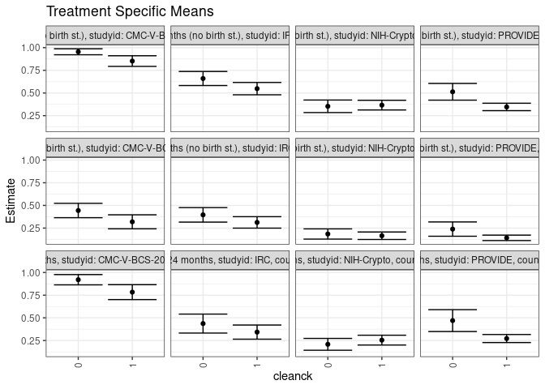

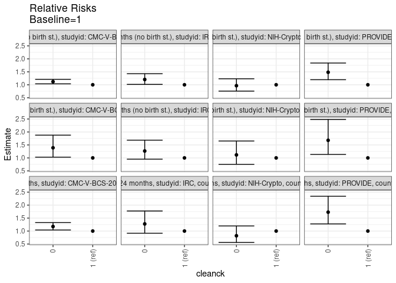

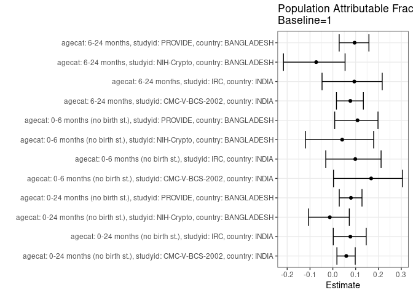

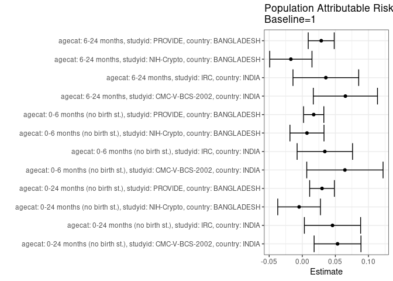

## Results Table

### Parameter: TSM

| agecat | studyid | country | intervention_level | baseline_level | estimate | ci_lower | ci_upper |
| --- | --- | --- | --- | --- | --- | --- | --- |
| 0-24 months (no birth st.) | CMC-V-BCS-2002 | INDIA | 1 | NA | 0.8521127 | 0.7936266 | 0.9105988 |
| 0-24 months (no birth st.) | CMC-V-BCS-2002 | INDIA | 0 | NA | 0.9545455 | 0.9215913 | 0.9874996 |
| 0-24 months (no birth st.) | IRC | INDIA | 1 | NA | 0.5480769 | 0.4803460 | 0.6158079 |
| 0-24 months (no birth st.) | IRC | INDIA | 0 | NA | 0.6597222 | 0.5822257 | 0.7372187 |
| 0-24 months (no birth st.) | NIH-Crypto | BANGLADESH | 1 | NA | 0.3662420 | 0.3129005 | 0.4195836 |
| 0-24 months (no birth st.) | NIH-Crypto | BANGLADESH | 0 | NA | 0.3532609 | 0.2841275 | 0.4223943 |
| 0-24 months (no birth st.) | PROVIDE | BANGLADESH | 1 | NA | 0.3461538 | 0.3052314 | 0.3870763 |
| 0-24 months (no birth st.) | PROVIDE | BANGLADESH | 0 | NA | 0.5132743 | 0.4210450 | 0.6055037 |
| 0-6 months (no birth st.) | CMC-V-BCS-2002 | INDIA | 1 | NA | 0.3191489 | 0.2420752 | 0.3962226 |
| 0-6 months (no birth st.) | CMC-V-BCS-2002 | INDIA | 0 | NA | 0.4437086 | 0.3643298 | 0.5230874 |
| 0-6 months (no birth st.) | IRC | INDIA | 1 | NA | 0.3125000 | 0.2494194 | 0.3755806 |
| 0-6 months (no birth st.) | IRC | INDIA | 0 | NA | 0.3958333 | 0.3158464 | 0.4758203 |
| 0-6 months (no birth st.) | NIH-Crypto | BANGLADESH | 1 | NA | 0.1656051 | 0.1244482 | 0.2067620 |
| 0-6 months (no birth st.) | NIH-Crypto | BANGLADESH | 0 | NA | 0.1847826 | 0.1286464 | 0.2409188 |
| 0-6 months (no birth st.) | PROVIDE | BANGLADESH | 1 | NA | 0.1423077 | 0.1122559 | 0.1723594 |
| 0-6 months (no birth st.) | PROVIDE | BANGLADESH | 0 | NA | 0.2389381 | 0.1602507 | 0.3176254 |
| 6-24 months | CMC-V-BCS-2002 | INDIA | 1 | NA | 0.7835052 | 0.7013218 | 0.8656885 |
| 6-24 months | CMC-V-BCS-2002 | INDIA | 0 | NA | 0.9204545 | 0.8637664 | 0.9771427 |
| 6-24 months | IRC | INDIA | 1 | NA | 0.3426573 | 0.2647009 | 0.4206138 |
| 6-24 months | IRC | INDIA | 0 | NA | 0.4367816 | 0.3323324 | 0.5412308 |
| 6-24 months | NIH-Crypto | BANGLADESH | 1 | NA | 0.2540323 | 0.1997854 | 0.3082791 |
| 6-24 months | NIH-Crypto | BANGLADESH | 0 | NA | 0.2080537 | 0.1427950 | 0.2733124 |
| 6-24 months | PROVIDE | BANGLADESH | 1 | NA | 0.2717949 | 0.2275931 | 0.3159967 |
| 6-24 months | PROVIDE | BANGLADESH | 0 | NA | 0.4696970 | 0.3491590 | 0.5902349 |

### Parameter: E(Y)

| agecat | studyid | country | intervention_level | baseline_level | estimate | ci_lower | ci_upper |
| --- | --- | --- | --- | --- | --- | --- | --- |
| 0-24 months (no birth st.) | CMC-V-BCS-2002 | INDIA | NA | NA | 0.9054054 | 0.8720096 | 0.9388012 |
| 0-24 months (no birth st.) | IRC | INDIA | NA | NA | 0.5937500 | 0.5423701 | 0.6451299 |
| 0-24 months (no birth st.) | NIH-Crypto | BANGLADESH | NA | NA | 0.3614458 | 0.3192090 | 0.4036825 |
| 0-24 months (no birth st.) | PROVIDE | BANGLADESH | NA | NA | 0.3759874 | 0.3382238 | 0.4137509 |
| 0-6 months (no birth st.) | CMC-V-BCS-2002 | INDIA | NA | NA | 0.3835616 | 0.3276935 | 0.4394298 |
| 0-6 months (no birth st.) | IRC | INDIA | NA | NA | 0.3465909 | 0.2968062 | 0.3963756 |
| 0-6 months (no birth st.) | NIH-Crypto | BANGLADESH | NA | NA | 0.1726908 | 0.1394601 | 0.2059214 |
| 0-6 months (no birth st.) | PROVIDE | BANGLADESH | NA | NA | 0.1595577 | 0.1310079 | 0.1881074 |
| 6-24 months | CMC-V-BCS-2002 | INDIA | NA | NA | 0.8486486 | 0.7968646 | 0.9004327 |
| 6-24 months | IRC | INDIA | NA | NA | 0.3782609 | 0.3154507 | 0.4410711 |
| 6-24 months | NIH-Crypto | BANGLADESH | NA | NA | 0.2367758 | 0.1949066 | 0.2786451 |
| 6-24 months | PROVIDE | BANGLADESH | NA | NA | 0.3004386 | 0.2583143 | 0.3425629 |

### Parameter: RR

| agecat | studyid | country | intervention_level | baseline_level | estimate | ci_lower | ci_upper |
| --- | --- | --- | --- | --- | --- | --- | --- |
| 0-24 months (no birth st.) | CMC-V-BCS-2002 | INDIA | 1 | 1 | 1.0000000 | 1.0000000 | 1.000000 |
| 0-24 months (no birth st.) | CMC-V-BCS-2002 | INDIA | 0 | 1 | 1.1202104 | 1.0373678 | 1.209669 |
| 0-24 months (no birth st.) | IRC | INDIA | 1 | 1 | 1.0000000 | 1.0000000 | 1.000000 |
| 0-24 months (no birth st.) | IRC | INDIA | 0 | 1 | 1.2037037 | 1.0150136 | 1.427471 |
| 0-24 months (no birth st.) | NIH-Crypto | BANGLADESH | 1 | 1 | 1.0000000 | 1.0000000 | 1.000000 |
| 0-24 months (no birth st.) | NIH-Crypto | BANGLADESH | 0 | 1 | 0.9645558 | 0.7557556 | 1.231043 |
| 0-24 months (no birth st.) | PROVIDE | BANGLADESH | 1 | 1 | 1.0000000 | 1.0000000 | 1.000000 |
| 0-24 months (no birth st.) | PROVIDE | BANGLADESH | 0 | 1 | 1.4827925 | 1.1958253 | 1.838624 |
| 0-6 months (no birth st.) | CMC-V-BCS-2002 | INDIA | 1 | 1 | 1.0000000 | 1.0000000 | 1.000000 |
| 0-6 months (no birth st.) | CMC-V-BCS-2002 | INDIA | 0 | 1 | 1.3902870 | 1.0293914 | 1.877709 |
| 0-6 months (no birth st.) | IRC | INDIA | 1 | 1 | 1.0000000 | 1.0000000 | 1.000000 |
| 0-6 months (no birth st.) | IRC | INDIA | 0 | 1 | 1.2666667 | 0.9519593 | 1.685413 |
| 0-6 months (no birth st.) | NIH-Crypto | BANGLADESH | 1 | 1 | 1.0000000 | 1.0000000 | 1.000000 |
| 0-6 months (no birth st.) | NIH-Crypto | BANGLADESH | 0 | 1 | 1.1158027 | 0.7535756 | 1.652144 |
| 0-6 months (no birth st.) | PROVIDE | BANGLADESH | 1 | 1 | 1.0000000 | 1.0000000 | 1.000000 |
| 0-6 months (no birth st.) | PROVIDE | BANGLADESH | 0 | 1 | 1.6790242 | 1.1354176 | 2.482894 |
| 6-24 months | CMC-V-BCS-2002 | INDIA | 1 | 1 | 1.0000000 | 1.0000000 | 1.000000 |
| 6-24 months | CMC-V-BCS-2002 | INDIA | 0 | 1 | 1.1747907 | 1.0402427 | 1.326741 |
| 6-24 months | IRC | INDIA | 1 | 1 | 1.0000000 | 1.0000000 | 1.000000 |
| 6-24 months | IRC | INDIA | 0 | 1 | 1.2746892 | 0.9163436 | 1.773170 |
| 6-24 months | NIH-Crypto | BANGLADESH | 1 | 1 | 1.0000000 | 1.0000000 | 1.000000 |
| 6-24 months | NIH-Crypto | BANGLADESH | 0 | 1 | 0.8190050 | 0.5603921 | 1.196964 |
| 6-24 months | PROVIDE | BANGLADESH | 1 | 1 | 1.0000000 | 1.0000000 | 1.000000 |
| 6-24 months | PROVIDE | BANGLADESH | 0 | 1 | 1.7281304 | 1.2753488 | 2.341661 |

### Parameter: PAR

| agecat | studyid | country | intervention_level | baseline_level | estimate | ci_lower | ci_upper |
| --- | --- | --- | --- | --- | --- | --- | --- |
| 0-24 months (no birth st.) | CMC-V-BCS-2002 | INDIA | 1 | NA | 0.0532927 | 0.0178815 | 0.0887039 |
| 0-24 months (no birth st.) | IRC | INDIA | 1 | NA | 0.0456731 | 0.0031783 | 0.0881678 |
| 0-24 months (no birth st.) | NIH-Crypto | BANGLADESH | 1 | NA | -0.0047963 | -0.0370637 | 0.0274712 |
| 0-24 months (no birth st.) | PROVIDE | BANGLADESH | 1 | NA | 0.0298335 | 0.0111430 | 0.0485240 |
| 0-6 months (no birth st.) | CMC-V-BCS-2002 | INDIA | 1 | NA | 0.0644127 | 0.0067526 | 0.1220728 |
| 0-6 months (no birth st.) | IRC | INDIA | 1 | NA | 0.0340909 | -0.0078022 | 0.0759840 |
| 0-6 months (no birth st.) | NIH-Crypto | BANGLADESH | 1 | NA | 0.0070857 | -0.0186455 | 0.0328169 |
| 0-6 months (no birth st.) | PROVIDE | BANGLADESH | 1 | NA | 0.0172500 | 0.0019393 | 0.0325607 |
| 6-24 months | CMC-V-BCS-2002 | INDIA | 1 | NA | 0.0651435 | 0.0166356 | 0.1136514 |
| 6-24 months | IRC | INDIA | 1 | NA | 0.0356035 | -0.0140498 | 0.0852568 |
| 6-24 months | NIH-Crypto | BANGLADESH | 1 | NA | -0.0172564 | -0.0491815 | 0.0146686 |
| 6-24 months | PROVIDE | BANGLADESH | 1 | NA | 0.0286437 | 0.0089909 | 0.0482966 |

### Parameter: PAF

| agecat | studyid | country | intervention_level | baseline_level | estimate | ci_lower | ci_upper |
| --- | --- | --- | --- | --- | --- | --- | --- |
| 0-24 months (no birth st.) | CMC-V-BCS-2002 | INDIA | 1 | NA | 0.0588606 | 0.0178699 | 0.0981405 |
| 0-24 months (no birth st.) | IRC | INDIA | 1 | NA | 0.0769231 | 0.0019391 | 0.1462735 |
| 0-24 months (no birth st.) | NIH-Crypto | BANGLADESH | 1 | NA | -0.0132696 | -0.1065958 | 0.0721858 |
| 0-24 months (no birth st.) | PROVIDE | BANGLADESH | 1 | NA | 0.0793471 | 0.0281963 | 0.1278056 |
| 0-6 months (no birth st.) | CMC-V-BCS-2002 | INDIA | 1 | NA | 0.1679331 | 0.0030847 | 0.3055225 |
| 0-6 months (no birth st.) | IRC | INDIA | 1 | NA | 0.0983607 | -0.0309466 | 0.2114494 |
| 0-6 months (no birth st.) | NIH-Crypto | BANGLADESH | 1 | NA | 0.0410310 | -0.1200232 | 0.1789263 |
| 0-6 months (no birth st.) | PROVIDE | BANGLADESH | 1 | NA | 0.1081112 | 0.0082466 | 0.1979199 |
| 6-24 months | CMC-V-BCS-2002 | INDIA | 1 | NA | 0.0767614 | 0.0159136 | 0.1338470 |
| 6-24 months | IRC | INDIA | 1 | NA | 0.0941243 | -0.0472404 | 0.2164064 |
| 6-24 months | NIH-Crypto | BANGLADESH | 1 | NA | -0.0728809 | -0.2163184 | 0.0536413 |
| 6-24 months | PROVIDE | BANGLADESH | 1 | NA | 0.0953397 | 0.0278309 | 0.1581606 |